# Analyzing Data for School District Improvement

or…Dancing the ‘Texas Twenty-Two-Step’

Professor Strabismus

University of Mars

2024-02-14

> **“My aim here is to contribute something to the improvement of learning in our school district; or any school district. My basic supposition is that school boards and administrators will welcome help to create rational policy action aimed at improving future learning in their district.”**

> — Professor Strabismis

> University of Mars

This paper is for those striving to improve the system of learning in their school district. It is directed toward school boards and superintendents, but anyone can use the theory and techniques to improve their teaching, classrooms, campuses, or departments. All that is needed is an open mind, willingness to do things a little differently, and a sense of urgency for getting things done. That sounds like Texans, to me.

**BACKGROUND**

All school boards and superintendents work very hard to ‘keep the lights on’ and improve learning in their districts and campuses (or ‘campi’ if you prefer the Latin form, because it *is* funnier).

Administrtation of budgets for facilities, equipment, personnel, safety and legislative compliance is a function of the managerial skill of the executive team and the school board. It is usually well managed with thoughtful planning and careful attention to fiscal details.

Improving learning in a district is a very different challenge and requires a different set of skills and knowledge. School boards, in particular, need help answering the important, practical questions such as:

- These numbers vary from period to period. **Does that variation signal anything important?**
- Is the variation due to normal **random fluctuations** that are present in all measurements, or to some strong influence now present in our system?
- Do these different numbers **constitute a trend** (good, or bad)?
- What is the **demonstrated capability** of our district to deliver STAAR scores (or any other results) in the varous categories and levels? In other words, what is **rational** to expect from our system **in the future?**
- **Should we continue** this approach, **abandon** it, or **continue it with modification?**
- Should we change something right away with an intervention, **or will that make things worse?**
- Are we improving, staying the same, or getting worse, and **how can we tell?**

Currently, there are dozens of situations where we need answers to questions like these.

Table 1: **Here are a just a few examples where we seek those answers, but find none:**

| Example Metric | Example Metric |
| --- | --- |
| STAAR scores | Survey results |
| District improvement plans | TAPR reports |
| Dropout rates | Pedagogy review |
| On-time arrivals for buses | Attendance rates |
| Superintendent evaluations | Graduation rates |
| Superintendent searches | Accountability ratings |

To help us answer policy questions like these the reports we use to evaluate the performance of programs, pedegogy, people, or anything else must come to us in a slightly different format than what we are used to seeing.

To be useful to us in leading our districts, any evaluation of results must provide evidence beyond ‘snapshot’ reports, or even two or three point comparisons. As discussed later, trends cannot be established with only two or three data points.

Here is an example of what a report looks like that contains the necessary information to help us. It analyzes public STAAR data provided by TEA, along with a brief interpretation of the chart:

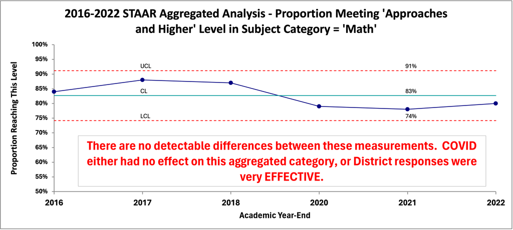

Fig: Data taken from 5 TEA “Snapshot” Reports and 1 TAPR report

INTERPRETING THE CHART

*With this one simple chart* we are in a position to answer each of the practical, important questions outlined earlier, at least for this particular STAAR category and level. Why would you settle for less? No other report even comes close.

**WHAT’S WRONG WITH THE REPORTS WE USE NOW?**

The TEA collects data from every school in Texas, performs various calculations, and produces reams of reports and tables summarizing their results by academic year. These reports consist primarily of calculations mandated by the state legislature, including those designed to allow districts to fulfill their public notification requirements.

These statistical summaries are available to the public and the school districts. Unfortunately for the public and the school districts, the information is not nearly as helpful as it could be. In fact, it takes so much ‘data wrangling’ to put it into a form that is remotely helpful for assessing and improving district and campus learning that it is simply not done.

Instead, administrators and school boards stare at endless rows and columns of mind-numbing data fragments that are ‘sliced and diced’ to an extent that even [the inventor of the Chop-O-Matic](https://en.wikipedia.org/wiki/Ron_Popeil) would be envious!

After ernestly pouring over such reports users have a sense that a Ouija Board might be better.

Here’s a partial example from a TEA report called a ‘Snapshot’:

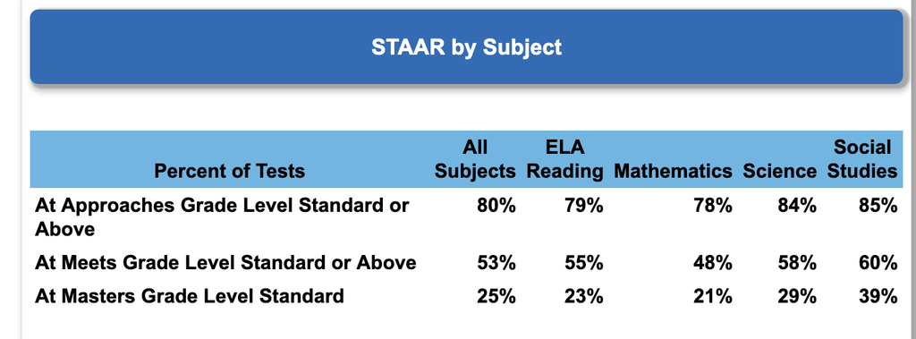

Fig: Small sample from TEAs Snapshot report

The entire report can be found here:

[(HTML)](https://rptsvr1.tea.texas.gov/cgi/sas/broker?_service=marykay&_program=perfrept.perfmast.sas&_debug=0&ccyy=2022&lev=D&id=094902&prgopt=reports%2Fsnapshot%2Fsnapshot.sas)

And, here’s a partial example from a TEA report called a ‘School Report Card’:

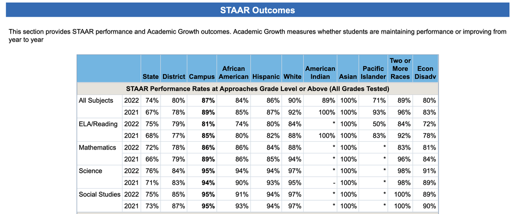

Fig: Small sample from TEAs School Report Card report

The entire report can be found here:

[(HTML)](https://rptsvr1.tea.texas.gov/cgi/sas/broker?_service=marykay&_program=perfrept.perfmast.sas&_debug=0&ccyy=2022&lev=C&prgopt=reports/src/src.sas&id=094902003)

**WHAT ARE THE CRUCIAL INGREDIENTS?**

What makes this report so powerful are these three features:

1. Prior period results for the process *plotted in time order*, oldest to newest, left to right (the more time periods presented the better);
2. An average (or median) for the entire group of results, plotted as a centerline; and
3. One simple calculation that sets the upper and lower bounds of results we can reasonably expect in the future.

*All we need are just those three things*. All three use simple arithmetic; not even algebra. But, none of the reports currently available have all three elements. Usually, they have none of the three.

Accordingly, those reports cannot answer these important questions. We are left only with a vague intuition about what the reports we get are trying to tell us. Intuition and personal experience have proven to be unreliable guides for action on policy, performance, and pedagogy.

As it turns out, there is a very simple solution - **IF** we can get our data into the right form for analysis. By reporting out results in the usual formats, neither the Texas Education Agency (TEA) nor the Texas Association of School Boards (TASB) can help us with this particular problem. It is up to us to take control of our own reporting needs.

For those thinking about the additional work needed to provide an anlysis like this when reporting data to the board, or to the public, or to each other please note that once the data was wrangled *it took less than 5 minutes to create the chart* using a very inexpensive Excel add-in!

Another Note: Even the extreme government measures imposed during the COVID-19 pandemic apparently were not disruptive enough to the district to create even a single point outside the natural limits. Or, the counter-measures employed by the district were very effective.

Technical Note For the Statistically Curious: The calculated limits are NOT set at 3 standard deviations above and below the average. The various statistical tests you learned in Statistics 101 cannot help you when your attention is focused on the future output of your district, campus, or pedagogy. They were designed to characterize a population as it exists at a single moment in time - how much or how many; without regard to why the population came to be the way that it is. Even the forecasting techniques are inappropriate for the task at hand.

**OBSTACLES TO IMPROVEMENT**

So, what is a school district to make of these mountains of aggregated numbers? Do they help districts improve learning in the future? In their present form, the answer is a resounding “NO!”

**OBSTACLE #1**

When it comes to improving the system of education in a district this ‘snapshot’ view of the data has several very big problems. One is aggregation. The TEA reports aggregate more than one rating level into a single reporting level. It combines the ‘Approaches Grade Level’ AND the ‘Meets Grade Level’ AND the ‘Masters Grade Level’ ratings all into one combined total and calls it the “Approaches Grade Level Standard AND HIGHER” level.

To make that category useful for improvement efforts we have to break it into the three separate levels, so each represents a single situation. Currently, that turns out to be quite tedious and extremely time-consuming. Just for fun, I call this situation ‘dancing the Texas Twenty-Two-Step’ - because it will take at least twenty-two additional steps to make the measurements useful!

The ‘Snapshot’ report offered by the TEA is a good example. My hat is off to their programmers. It is an impressive compilation of statistics all in one place. It is well-suited for the needs of the TEA and their reporting responsibilities to the legislature; but completely ill-suited for helping the concerned school board, superintendent, or even tax-paying citizen make an analysis aimed at improving future learning. One might call it a triumph of computation over value.

Although this aggregation permits TEA to render abstract judgments about a district or campus, the lack of specificity renders these reports unsuitable for understanding any particular process, category or level your board may be interested in monitoring or improving.

By analogy, it is like trying to repair your car by reading the overall repair records of similar models. What you need is diagnostic data about what is happening (or not happening) with your **specific** vehicle.

Here is an example of aggregated STAAR categories in a TEA report:

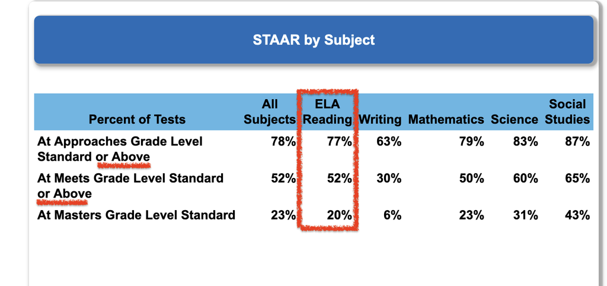

Fig: The first two rows contain more than one achievement level

**OBSTACLE #2**

These reports are ‘ill-suited’ for district improvement efforts for another reason: the TEA reports are **siloed by academic year**, making it nearly impossible to create a time-period-by-time-period data frame of any categories or levels the board may wish to analyze. In fact, without time-period-by-time-period data *no meaningful analysis is possible.*

**OBSTACLE #3**

> **“At sea one day you will smell land where there be no land.”**

> — Elijah, to Ishmael and Queequeg

> *Moby Dick (film, 1956)*

Obstacle number 3 is not related to the TEA reports at all. It has to do with our human nature (or, as Jessica Rabbit put it in the 1988 film ‘Who Framed Roger Rabbit’: “I’m not bad, I’m just drawn that way!”).

For survival, humans evolved with the ability to rapidly detect patterns. That instinct can lead us astray when studying our data. Unfortunately, we quite naturally see ‘trends’ and ‘signals’ where there are none.

Consider that for any three measurements there are at least 10 completely random arrangements that can arise. And, we have created names to categorize these completely artificial ‘trends’ that we think we see:

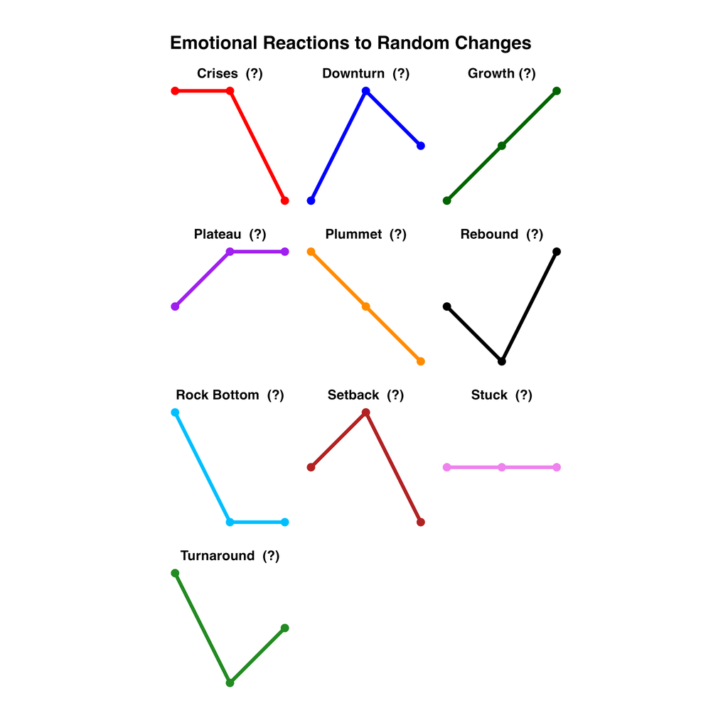

Fig: Ten random arrangements of 3 measurements

How many of those ‘trends’ do you see in this example of TEA data placed on a bar chart?

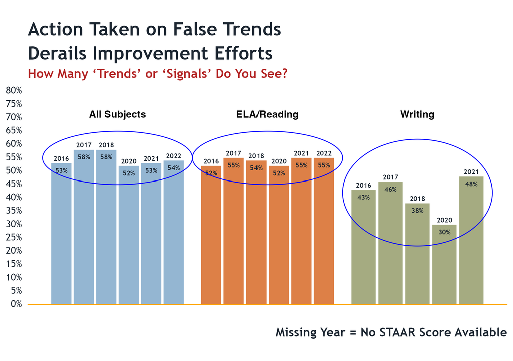

Fig: Do you see any trends or signals?

So, we need a report that will separate the ‘common cause’ variation we see from the ‘special cause’ variation that signals a true trend or a shock to the system. Our current reports do not make that separation for us.

**OBSTACLE #4**

Obstacle #3 is about our perceptions. Obstacle #4 is about our emotions. We have a very human impulse to intervene any time we feel something is ‘wrong’ and needs to be ‘fixed.’ The incentives for board members to seek interventions are many and varied, but the type of changes proposed really matters. This is a situation where board members must remain vigilant about getting involved in matters that are administrative (the responsibility of the superintendent) and not policy (the responsibility of the board).

The problem arises if we react to a result that is merely random, ‘common-cause’ variation as if it were a ‘special cause’ signal. This is called ‘tampering’ and will make things worse. The variation we see will increase and our good results will be diluted accordingly. At worse, we can de-stabalize a stable system.

This can be particularly acute when there is an ‘incident’ involving misfortune or safety. Although rare, these events may be quite upsetting. However, trying to keep unpleasant events from ‘ever happening again’ can make things worse, not better.

It is part of the leadership responsibility of boards to provide a measured and rational response when misfortune comes our way. Knowing about ‘common cause’ and ‘special cause’ variation can help us do that.

**ANALYSIS - WHAT IS IT?**

Analysis was developed to help separate the actual signals in the data from the random fluctuations that are always present in any measurement.

In this context analysis means to subject the data to ONE very simple statistical test to see if the system (or process) producing the data shows evidence of being in a *stable state*, with a *predictable capability*.

If stable, this capability will show a range of values that constitute ‘normal’ for the process. Until the process itself changes in some fundamental way future measurements will wander between the capability limits; sometimes upward, sometimes downward, sometimes the same.

Let’s look at an example. A visual is always better than mere words.

**GETTING BLOOD FROM THE TURNIP**

After an embarrassing amount of time spent ‘data wrangling’ I was able to construct from the 5 available TEA ‘Snapshot’ reports a small time-period-by-time-period data frame for STAAR scores for all subject-matter categories at the district-level for the academic years ended 2016-2022. (No STAAR scores were available for the 2019 academic year.)

The TEA STARR Data Divided Into Constituent Parts for the subject ‘Math’

Subject = Math, with Proportions Broken Into Constituent Parts.

| Year | Approaches | Mts Std | Masters | Combined | Failing |
| --- | --- | --- | --- | --- | --- |
| 2016 | 31% | 29% | 24% | 84% | 16% |
| 2017 | 27% | 31% | 30% | 88% | 12% |
| 2018 | 25% | 29% | 33% | 87% | 13% |
| 2020 | 29% | 27% | 23% | 79% | 21% |
| 2021 | 30% | 27% | 21% | 78% | 22% |
| 2022 | 31% | 31% | 18% | 80% | 20% |

An amazing amount of very useful information is now available to us using just this small data frame.

The reaction of management (which includes the school board) should be completely different if the system or process indicates a stable state (predictable) than when it shows signals of being unstable (statistically speaking, of course).

Reacting to so-called performance indicators that fall within the ‘normal’ range of a predictable process is *harmful.* It makes things *worse*; no matter how emotional you may become if you think you see things ‘going in the wrong direction.’

Reacting to indicators falling outside the identified ‘normal’ range is *productive*. If the indicator is in the ‘good’ direction efforts to identify the causes and duplicate them are almost always successful. If they fall in the ‘bad’ direction, efforts to identify the causes and remove them are worthwhile.

All data I’ve seen so far as a board member are descriptive only, with no analysis present. The most important step, analysis, is missing.

**A SOLUTION**

To improve we must move from a ‘snapshot’ point of view to an ‘analysis’ point of view. *There is no in-between.* That means the data we seek must include the context of time. All improvement work requires time-period-by-time-period data.

The crucial information for analysis of process and district capability (and the prediction of future performance) is contained in the order of occurrence found in the time-period-by-time-period data. *The more periods included in the analysis, the stronger the evidence for your inferences from the charts.*

Humans naturally seek context. That is where notions such as ‘this month vs last month vs YTD vs a year ago this month’ arose. Those are insufficient for analysis, but they soothe our need for context of some sort.

Managing a district consists of budgeting, administration, and resource allocation. Essential, to be sure.

Budgeting is based on (hopefully) very careful calculations of estimated revenue and expenses expected for the next academic year. Resource allocation within and between budget categories are determined by the priorities and risk tolerance of the Board of Trustees.

Resources for facility expansion and improvement depend on both the demographics of the district and the vision of the Executive team.

District improvement is a totally different exercise. To improve, boards must be able to assess the demonstrated capability and effectiveness of learning in their district. .

The context of **TIME** is crucial to assess the capability and effectiveness of any system or process, including learning.

Nearly every district has a ‘reputation’ (for better or worse) in the region, state, or nation. Some districts have reputations for great athletic programs, some for music/arts, some for academics. Those reputations are built over time.

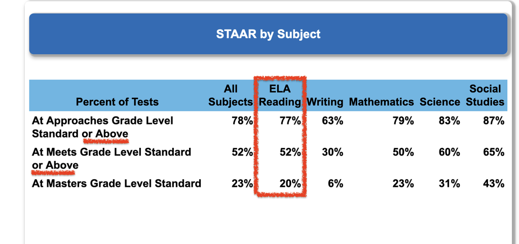

The section reporting STAAR scoring by ethnicity:

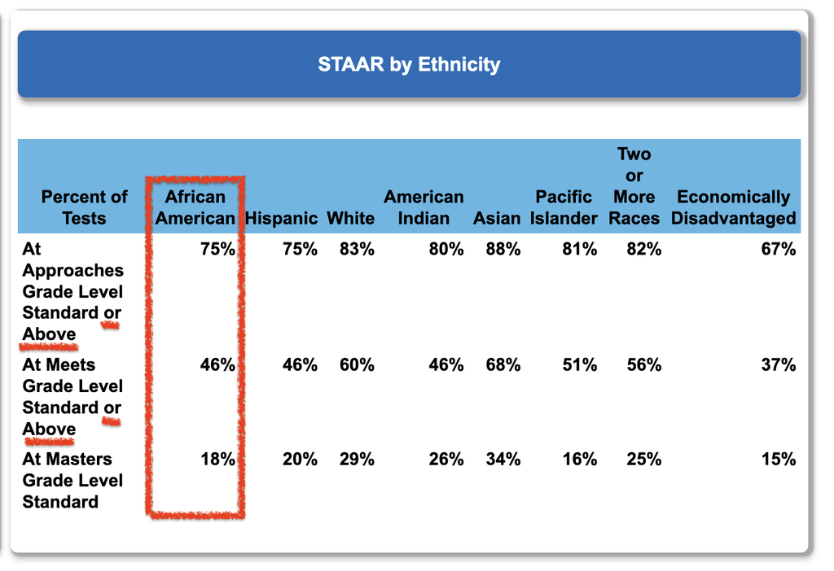

School boards deal with two types data:

- Enumerative: quantitative information limited to a description of the past, usually for compliance purposes.
- Analytic: data subjected to analysis for estimating a causal explanation of phenomena observed in the past, with the aim of improvement in the future.

The aim of a TEA report is descriptive. How many or how much. They are estimates of how many people belong to this or that category for a specified academic year. Or, to report the financial aspects of operations during the school year. Their aim is NOT to find out WHY there are so many or so few in this or that category: merely how many.

School boards should look to take action on the district-level processes, or cause-system, that produced the data described in the TEA reports, the aim being to improve learning in the future. Interest centers on future learning, not the learning of the past. For example : adopt Policy B over A, or hold on to Policy A, or continue the study of Policy B.

Enumerative study: A statistical study in which action will be taken on the material in the frame being studied.

Analytic study: A statistical study in which action will be taken on the process or cause-system that produced the frame being studied. The aim being to improve practice in the future.

In other words, an enumerative study is a statistical study in which the focus is on judgment of results, and an analytic study is one in which the focus is on improvement of the process or system which created the results being evaluated and which will continue creating results in the future. A statistical study can be enumerative or analytic, but it cannot be both.

Statistical theory in enumerative studies is used to describe the precision of estimates and the validity of hypotheses for the population studied. In analytical studies, the standard error of a statistic does not address the most important source of uncertainty, namely, the change in study conditions in the future.

Deming’s philosophy is that management should be analytic instead of enumerative. In other words, management should focus on improvement of processes for the future instead of on judgment of current results.

That is the least of our problems. The murders may be related, as in a war between drug barons. If so, the model is wrong, since it assumes that murders are independent. Or the methods of counting might have changed from one year to the next (are you counting all suspicious deaths, or only cases solved?). Without knowing about such things we cannot predict from these figures to what will happen next year. So if we want to draw the conclusion that the 27% reduction is a “real” one, that is, one which will continue in the future, we must use knowledge about the problem that is not given by those figures alone. Even less can we predict accurately what would happen in a different city, or a different country. The causes of crime, or the effect of a change in policing methods, may be completely different.

Then your actions on the basis of the information available become much more effective. Even more, your actions to get more information improve, because when you understand the sources of uncertainty, you understand how to reduce it.

It seems that it might help if we could look at, say, six years of the ‘All Subjects’ category at one time.

If we try to look at the data over the last 6 years we still have the problem of the ‘TEA Twenty-Two Step’!

The next rating category also contains more than one rating level. It combines the ‘At Meets’ AND the ‘At Masters’ into one combined total.

This rating category is the exception; it contains only one rating level. It shows ONLY the ‘At Masters’ level totals.

**WHY MORE THAN 3 TIME PERIODS ARE NEEDED**

Here we see a comprehensive view of all subject categories for the compound level of achievement called ‘Meets Grade Level Standard **AND ABOVE**’ for all years in the sample:

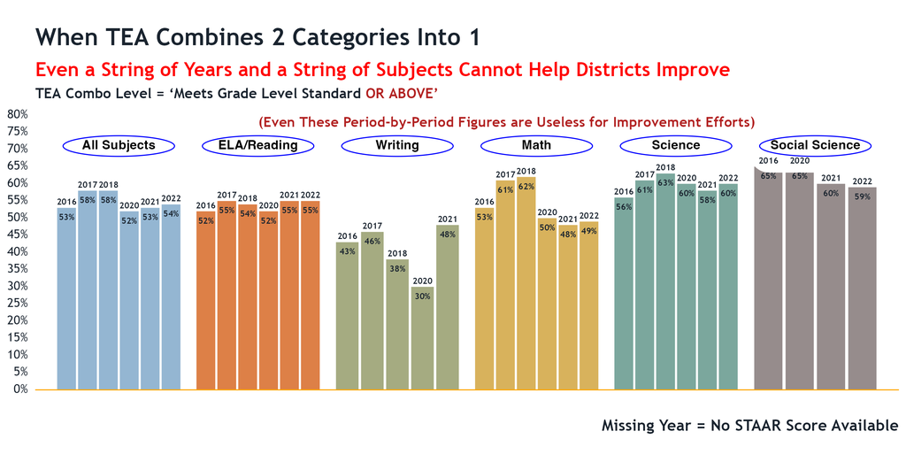

Fig: IS THIS A BUSY GRAPH, OR WHAT!? Still, take a moment to read it.

Interest is focused on *the system (or process) that will produce the future output*; not the output of the past.